# NZ GREEN Grid Household Electricity Demand Data

EECA Data Analysis (Part B) GXP Data Report v0.5

Ben Anderson

Last run at: 2019-09-13 13:36:07 (Pacific/Auckland)

# 1 About

## 1.1 Citation

If you wish to use any of the material from this report please cite as:

- Ben Anderson (2019) *NZ GREEN Grid Household Electricity Demand Data: EECA Data Analysis (Part B) GXP Data Report v0.5*, [Centre for Sustainability](http://www.otago.ac.nz/centre-sustainability/), University of Otago: Dunedin.

This work is (c) 2019 the authors. Usage right are specified in the License section (1.3).

## 1.2 Report circulation

- Public – this report is intended for publication following EECA approval.

## 1.3 License

This work is made available under the Creative Commons [Attribution-ShareAlike 4.0 International (CC BY-SA 4.0) License](https://creativecommons.org/licenses/by-sa/4.0/).

This means you are free to:

- *Share* — copy and redistribute the material in any medium or format
- *Adapt* — remix, transform, and build upon the material for any purpose, even commercially.

Under the following terms:

- *Attribution* — You must give appropriate credit, provide a link to the license, and indicate if changes were made. You may do so in any reasonable manner, but not in any way that suggests the licensor endorses you or your use.
- *ShareAlike* — If you remix, transform, or build upon the material, you must distribute your contributions under the same license as the original.
- *No additional restrictions* — You may not apply legal terms or technological measures that legally restrict others from doing anything the license permits.

**Notices:**

- You do not have to comply with the license for elements of the material in the public domain or where your use is permitted by an applicable exception or limitation.
- No warranties are given. The license may not give you all of the permissions necessary for your intended use. For example, other rights such as publicity, privacy, or moral rights may limit how you use the material.

For the avoidance of doubt and explanation of terms please refer to the full [license notice](https://creativecommons.org/licenses/by-sa/4.0/) and [legal code](https://creativecommons.org/licenses/by-sa/4.0/legalcode).

## 1.4 History

You may not be reading the most recent version of this report. Please check:

- the github [R code repository](https://cfsotago.github.io/GREENGridEECA/);
- our [issues list](https://github.com/CfSOtago/GREENGridEECA/issues) for any unfixed problems;
- our [project documentation site](https://cfsotago.github.io/GREENGridEECA/) and specifically;
- this [report’s edit history](https://github.com/CfSOtago/GREENGridEECA/commits/master/reports/partA_dataProcessing)

## 1.5 Support

This work was supported by:

- The New Zealand Energy Efficiency and Conservation Authority ([EECA](https://www.eeca.govt.nz/))

# 2 Introduction

This report uses the Electricity Authority EMI [grid export database](https://www.emi.ea.govt.nz/Wholesale/Datasets/Metered_data/Grid_export) for 2015 to:

- identify system peak half-hours for the regions of Taranaki and Hawke’s Bay for use in the Part B data analysis

This report describes the results of this work and directs the reader to relevant R code where necessary.

All code used to create this report is available from:

- https://github.com/CfSOtago/GREENGridEECA

The archived and most recent version of the report is available from:

- https://cfsotago.github.io/GREENGridEECA/

# 3 Data

"Grid exit point (GXP)

A grid exit point (GXP) is defined in Part 1 of the Code and means any point of connection on the grid at which electricity predominantly flows out of the grid or is determined as being such by the Authority following an application in accordance with clause 13.28. Any such point of connection may, at any given time, be a GXP or a GIP, but may not be both at the same time."

For (very little) further information see the [EMI glossary](https://www.emi.ea.govt.nz/Glossary#G).

We use the GXP data to identify local (regional) system peak load half-hours for Hawke’s Bay and Taranaki as this matches the [GREEN Grid household sample location](https://cfsotago.github.io/GREENGridData/overviewReport_v1.0.html).

Start date: 2015-06-01

End date: 2015-08-31

Selected GXPs for the regions we are interested in:

Table 3.1: Summary of MWh per half hour by region, GXP nodes selected and network codes

| regionName | node | NWK_Code | nHalfHours | meanMWh |
| --- | --- | --- | --- | --- |
| Hawke’s bay | FHL0331 | HAWK | 4416 | 16.07 |
| Hawke’s bay | RDF0331 | HAWK | 4416 | 17.19 |
| Hawke’s bay | WTU0331 | HAWK | 4416 | 27.68 |
| Taranaki | CST0331 | POCO | 4416 | 17.45 |
| Taranaki | HUI0331 | POCO | 4416 | 5.86 |
| Taranaki | HWA0331 | POCO | 4416 | 9.58 |
| Taranaki | NPL0331 | POCO | 4416 | 5.57 |
| Taranaki | NPL0331 | PTNP | 4416 | 0.05 |
| Taranaki | OPK0331 | POCO | 4416 | 2.42 |
| Taranaki | SFD0331 | POCO | 4416 | 7.17 |
| Taranaki | WGN0331 | POCO | 4416 | 8.02 |

Note that NPL0331 in Taranaki has two network codes - presumably it feeds two networks? In what follows we simply sum the kWh for all half-hours for all nodes for each region.

# 4 EMI GXP data

Figure 4.1 shows the mean total network electricity export in these regions as a data sense-check.

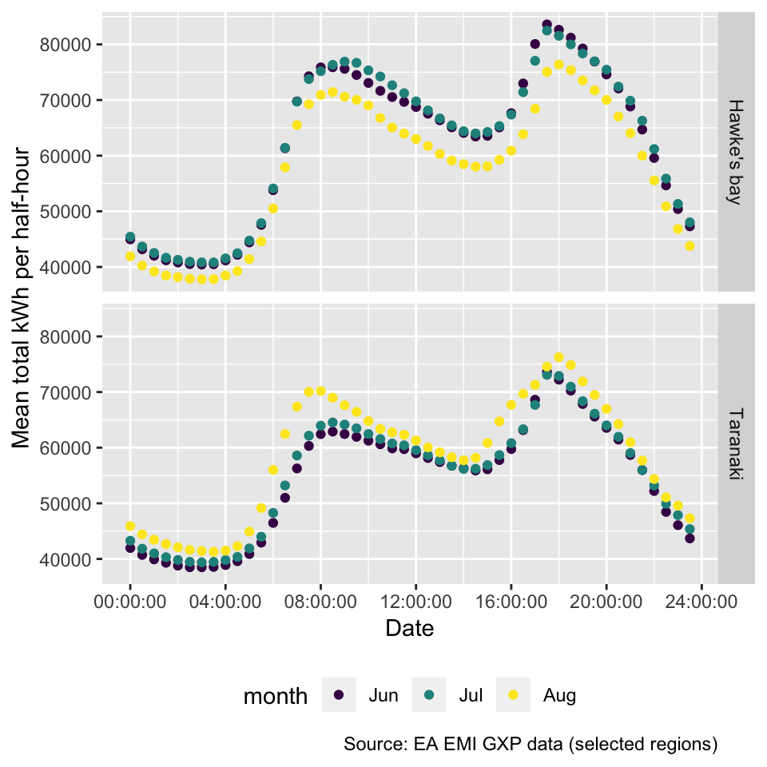

Figure 4.1: Mean total kWh per half hour by month and region

# 5 Top 100 ‘peaks’

## 5.1 Hawke’s Bay

Figure 5.1 shows the total network electricity export in this region as a data sense-check.

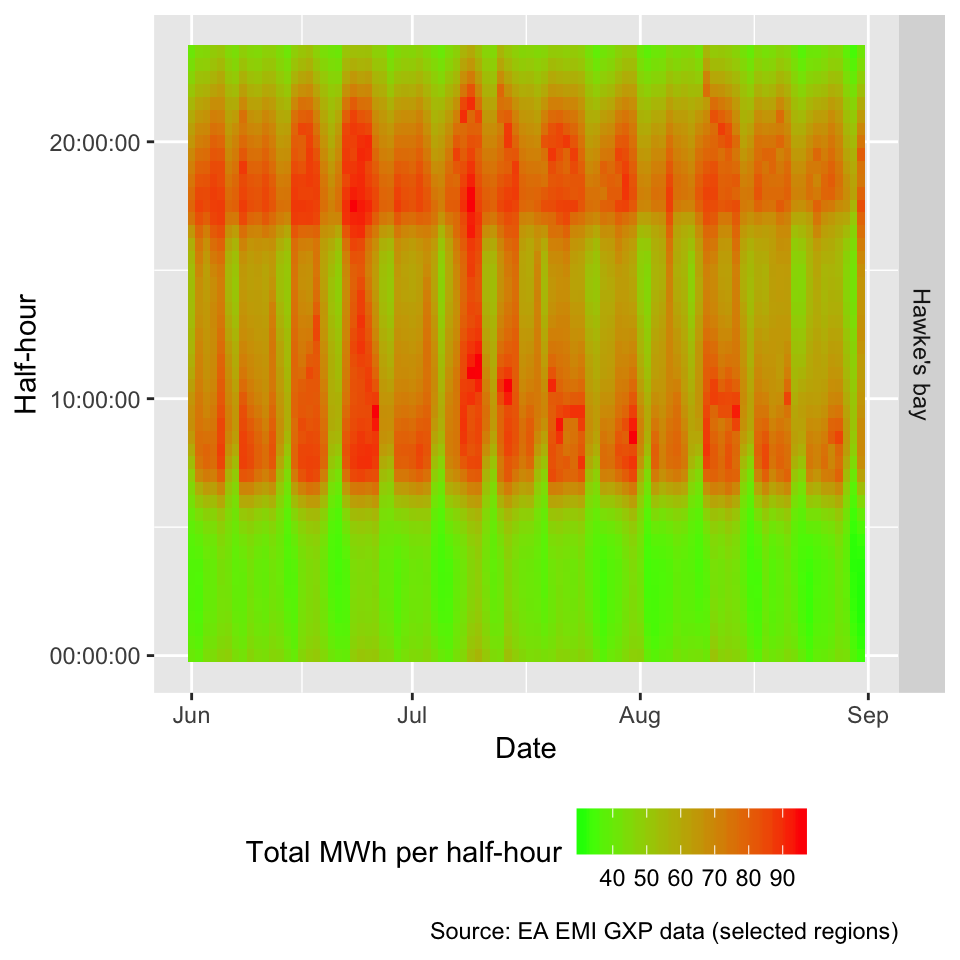

Figure 5.1: Hawke’s Bay: Total MWh per half hour

Table 5.1 shows the top 10 peak demand periods.

Table 5.1: Top 10 of top 100 Hawke’s Bay peak demand half-hours

| regionName | Time_Period | hms | rDateTime | weekdays | peakPeriod | sumkWh |
| --- | --- | --- | --- | --- | --- | --- |
| Hawke’s bay | TP23 | 11:00:00 | 2015-07-10 11:00:00 | Weekdays | Day time | 95432 |
| Hawke’s bay | TP36 | 17:30:00 | 2015-07-09 17:30:00 | Weekdays | Evening peak | 94725 |
| Hawke’s bay | TP24 | 11:30:00 | 2015-07-10 11:30:00 | Weekdays | Day time | 94214 |
| Hawke’s bay | TP20 | 09:30:00 | 2015-06-26 09:30:00 | Weekdays | Day time | 94115 |
| Hawke’s bay | TP36 | 17:30:00 | 2015-06-23 17:30:00 | Weekdays | Evening peak | 94018 |
| Hawke’s bay | TP23 | 11:00:00 | 2015-07-09 11:00:00 | Weekdays | Day time | 93898 |
| Hawke’s bay | TP22 | 10:30:00 | 2015-07-14 10:30:00 | Weekdays | Day time | 93834 |
| Hawke’s bay | TP18 | 08:30:00 | 2015-07-31 08:30:00 | Weekdays | Morning peak | 93627 |
| Hawke’s bay | TP37 | 18:00:00 | 2015-07-09 18:00:00 | Weekdays | Evening peak | 93603 |
| Hawke’s bay | TP19 | 09:00:00 | 2015-07-21 09:00:00 | Weekdays | Day time | 92724 |

Table 5.2 shows when the top 100 peak demand periods occured.

Table 5.2: Hawke’s Bay peak demand half-hours

| Time_Period | hms | weekdays | peakPeriod | nHalfHours |
| --- | --- | --- | --- | --- |
| TP36 | 17:30:00 | Weekdays | Evening peak | 12 |
| TP37 | 18:00:00 | Weekdays | Evening peak | 9 |
| TP16 | 07:30:00 | Weekdays | Morning peak | 6 |
| TP22 | 10:30:00 | Weekdays | Day time | 6 |
| TP35 | 17:00:00 | Weekdays | Evening peak | 6 |
| TP39 | 19:00:00 | Weekdays | Evening peak | 6 |
| TP17 | 08:00:00 | Weekdays | Morning peak | 5 |
| TP18 | 08:30:00 | Weekdays | Morning peak | 5 |
| TP20 | 09:30:00 | Weekdays | Day time | 5 |
| TP38 | 18:30:00 | Weekdays | Evening peak | 5 |
| TP40 | 19:30:00 | Weekdays | Evening peak | 5 |
| TP19 | 09:00:00 | Weekdays | Day time | 4 |
| TP41 | 20:00:00 | Weekdays | Evening peak | 4 |
| TP21 | 10:00:00 | Weekdays | Day time | 3 |
| TP23 | 11:00:00 | Weekdays | Day time | 3 |
| TP25 | 12:00:00 | Weekdays | Day time | 3 |
| TP34 | 16:30:00 | Weekdays | Day time | 3 |
| TP24 | 11:30:00 | Weekdays | Day time | 2 |
| TP26 | 12:30:00 | Weekdays | Day time | 2 |
| TP42 | 20:30:00 | Weekdays | Evening peak | 2 |
| TP27 | 13:00:00 | Weekdays | Day time | 1 |
| TP33 | 16:00:00 | Weekdays | Day time | 1 |
| TP43 | 21:00:00 | Weekdays | Late evening | 1 |
| TP44 | 21:30:00 | Weekdays | Late evening | 1 |

## 5.2 Taranaki

Figure 5.2 shows the total network electricity export in this region as a data sense-check.

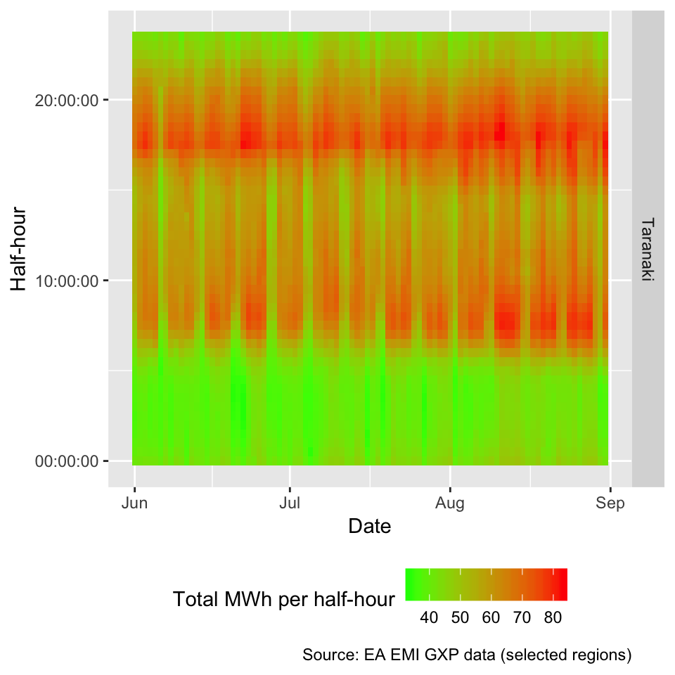

Figure 5.2: Taranaki: Total MWh per half hour

Table 5.3 shows the top 10 peak demand periods.

Table 5.3: Top 10 of top 100 Taranaki peak demand half-hours

| regionName | Time_Period | hms | rDateTime | weekdays | peakPeriod | sumkWh |
| --- | --- | --- | --- | --- | --- | --- |
| Taranaki | TP37 | 18:00:00 | 2015-08-11 18:00:00 | Weekdays | Evening peak | 83244 |
| Taranaki | TP38 | 18:30:00 | 2015-08-11 18:30:00 | Weekdays | Evening peak | 82281 |
| Taranaki | TP37 | 18:00:00 | 2015-08-10 18:00:00 | Weekdays | Evening peak | 81820 |
| Taranaki | TP37 | 18:00:00 | 2015-08-18 18:00:00 | Weekdays | Evening peak | 81664 |
| Taranaki | TP36 | 17:30:00 | 2015-08-18 17:30:00 | Weekdays | Evening peak | 81582 |
| Taranaki | TP36 | 17:30:00 | 2015-06-22 17:30:00 | Weekdays | Evening peak | 81563 |
| Taranaki | TP36 | 17:30:00 | 2015-08-31 17:30:00 | Weekdays | Evening peak | 81461 |
| Taranaki | TP36 | 17:30:00 | 2015-08-24 17:30:00 | Weekdays | Evening peak | 80993 |
| Taranaki | TP36 | 17:30:00 | 2015-06-23 17:30:00 | Weekdays | Evening peak | 80841 |
| Taranaki | TP37 | 18:00:00 | 2015-08-24 18:00:00 | Weekdays | Evening peak | 80661 |

Table 5.4 shows when the 100 peak demand periods occured.

Table 5.4: Taranaki peak demand half-hours

| Time_Period | hms | weekdays | peakPeriod | nHalfHours |
| --- | --- | --- | --- | --- |
| TP37 | 18:00:00 | Weekdays | Evening peak | 26 |
| TP36 | 17:30:00 | Weekdays | Evening peak | 24 |
| TP38 | 18:30:00 | Weekdays | Evening peak | 12 |
| TP16 | 07:30:00 | Weekdays | Morning peak | 11 |
| TP17 | 08:00:00 | Weekdays | Morning peak | 9 |
| TP34 | 16:30:00 | Weekdays | Day time | 5 |
| TP15 | 07:00:00 | Weekdays | Morning peak | 3 |
| TP35 | 17:00:00 | Weekdays | Evening peak | 3 |
| TP18 | 08:30:00 | Weekdays | Morning peak | 2 |
| TP37 | 18:00:00 | Weekends | Evening peak | 2 |
| TP39 | 19:00:00 | Weekdays | Evening peak | 2 |
| TP40 | 19:30:00 | Weekdays | Evening peak | 1 |

# 6 Summary

This report used the EA EMI GXP data to:

- identify the ‘peak’ demand half hours in the two regions under study.

This report described the results of this work and directed the reader to relevant R code where necessary.

All code used to create this report is available from:

- https://github.com/CfSOtago/GREENGridEECA

The archived and most recent version of the report is available from:

- https://cfsotago.github.io/GREENGridEECA/

The selected half-hours can be found in the [github repo](https://cfsotago.github.io/GREENGridEECA/data/).

# 7 Data Annex

## 7.1 GXP summary

Descriptive statistics for original EA GXP data:

```
## Skim summary statistics
##  n obs: 10
##  n variables: 3
##
## ── Variable type:character ─────────────────────────────────────────────────────────────────────────────────────────────────────────
##     variable missing complete  n min max empty n_unique
##         node       0       10 10   7   7     0       10
##       region       0       10 10   1   1     0        2
##  region name       0       10 10   8  11     0        2
```

# 8 Runtime

Analysis completed in 2.66 seconds ( 0.04 minutes) using knitr in [RStudio](http://www.rstudio.com) with R version 3.5.2 (2018-12-20) running on x86_64-apple-darwin15.6.0.

# 9 R environment

## 9.1 R packages used

- base R (R Core Team 2016)
- bookdown (Xie 2016a)
- data.table (Dowle et al. 2015)
- ggplot2 (Wickham 2009)
- kableExtra (Zhu 2018)
- knitr (Xie 2016b)
- lubridate (Grolemund and Wickham 2011)
- rmarkdown (Allaire et al. 2018)

# References

Allaire, JJ, Yihui Xie, Jonathan McPherson, Javier Luraschi, Kevin Ushey, Aron Atkins, Hadley Wickham, Joe Cheng, and Winston Chang. 2018. *Rmarkdown: Dynamic Documents for R*. https://CRAN.R-project.org/package=rmarkdown.

Dowle, M, A Srinivasan, T Short, S Lianoglou with contributions from R Saporta, and E Antonyan. 2015. *Data.table: Extension of Data.frame*. https://CRAN.R-project.org/package=data.table.

Grolemund, Garrett, and Hadley Wickham. 2011. “Dates and Times Made Easy with lubridate.” *Journal of Statistical Software* 40 (3): 1–25. http://www.jstatsoft.org/v40/i03/.

R Core Team. 2016. *R: A Language and Environment for Statistical Computing*. Vienna, Austria: R Foundation for Statistical Computing. https://www.R-project.org/.

Wickham, Hadley. 2009. *Ggplot2: Elegant Graphics for Data Analysis*. Springer-Verlag New York. http://ggplot2.org.

Xie, Yihui. 2016a. *Bookdown: Authoring Books and Technical Documents with R Markdown*. Boca Raton, Florida: Chapman; Hall/CRC. https://github.com/rstudio/bookdown.

———. 2016b. *Knitr: A General-Purpose Package for Dynamic Report Generation in R*. https://CRAN.R-project.org/package=knitr.

Zhu, Hao. 2018. *KableExtra: Construct Complex Table with ’Kable’ and Pipe Syntax*. https://CRAN.R-project.org/package=kableExtra.